# Case 31: Summary of Data Analysis for H5a-H5d

- Show All Code
- Hide All Code
- View Source

Employees Federal Credit Union

Author

Simran Kaur

Published

November 16, 2026

**Show R code**

```r
library(tidyverse)
library(haven)
library(psych)      # corr.test()
library(car)        # vif(), avPlots()
library(lmtest)     # bptest()
library(knitr)
options(knitr.kable.NA = "")

green <- "#245e52"
ink   <- "#233c38"

theme_set(
  theme_minimal(base_size = 15, base_family = "sans") +
    theme(panel.grid.minor = element_blank(),
          plot.title.position = "plot",
          axis.text  = element_text(color = ink, face = "bold"),
          axis.title = element_text(color = ink, face = "bold"))
)

fmt_p <- function(p) ifelse(p < .001, "< .001", sprintf("%.3f", p))

efcu <- read_sav("Case 31 Data_efcu_4.sav")
h5 <- zap_labels(efcu) |>
  select(Q37_r, q31, q32, q33, q34) |>
  drop_na()                          # members who answered all five (n = 121)

labs5 <- c(Q37_r = "Q37r: Overall management & operation",
           q31 = "Q31: Info kept confidential",
           q32 = "Q32: Prompt loan processing",
           q33 = "Q33: Services meet needs",
           q34 = "Q34: Loan applications simple")
```

## About this report

**H5a–H5d** ask what drives members’ **overall rating of how EFCU is managed and operated** (Q37r): **confidentiality** (Q31, H5a), **prompt loan processing** (Q32, H5b), **services meeting needs** (Q33, H5c) and **simple loan applications** (Q34, H5d).

**Why one multiple regression:** all four hypotheses share **the same dependent variable**, and every variable is a **1–5 interval rating**. One model tests all four drivers **at once**, and each coefficient shows a driver’s effect **while holding the other three constant**. That matters because some drivers overlap, like Q32 and Q34 (*r* = .40). The analysis uses the **121 members** who answered all five questions.

## H5: Descriptive statistics

**Show R code**

```r
ct <- corr.test(h5)
tibble(Variable = labs5,
       Mean = sapply(h5, mean), SD = sapply(h5, sd),
       `% favorable` = c(100 * mean(h5$Q37_r >= 4), sapply(h5[-1], \(x) 100 * mean(x >= 4))),
       `r with Q37r` = c(NA, ct$r["Q37_r", -1]),
       p = c("", fmt_p(ct$p[-1, "Q37_r"]))) |>   # unadjusted p (lower triangle)
  kable(digits = 2)
```

Table 1: Descriptive statistics and correlation with the overall rating (Q37r)

| Variable | Mean | SD | % favorable | r with Q37r | p |
| --- | --- | --- | --- | --- | --- |
| Q37r: Overall management & operation | 4.07 | 0.73 | 84.30 |  |  |
| Q31: Info kept confidential | 3.93 | 0.68 | 77.69 | 0.33 | < .001 |
| Q32: Prompt loan processing | 3.74 | 0.80 | 61.16 | 0.43 | < .001 |
| Q33: Services meet needs | 3.62 | 0.67 | 61.16 | 0.37 | < .001 |
| Q34: Loan applications simple | 3.47 | 0.79 | 58.68 | 0.08 | 0.406 |

*% favorable = good or excellent for Q37r, agree or strongly agree for Q31–Q34.*

**Show R code**

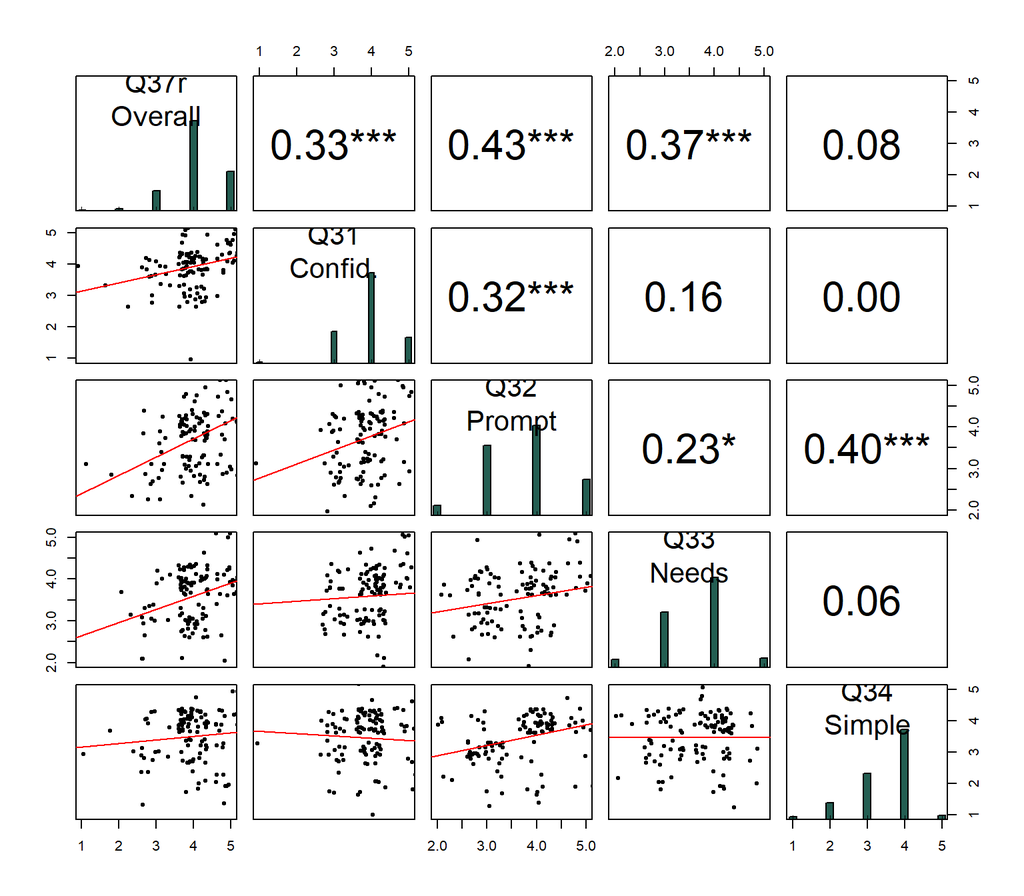

Figure 1: Scatterplot matrix: histograms, scatterplots with fit lines, and correlations

```r
pairs.panels(h5, jiggle = TRUE, factor = 2, hist.col = green, lm = TRUE,
             density = FALSE, ellipses = FALSE, stars = TRUE,
             labels = c("Q37r\nOverall", "Q31\nConfid.", "Q32\nPrompt", "Q33\nNeeds", "Q34\nSimple"))
```

The overall rating rises with **loan speed, meeting needs and confidentiality**, while the line for **Q34 is almost flat** (Figure 1).

## H5: Multiple regression

**Show R code**

```r
h5_fit <- lm(Q37_r ~ q31 + q32 + q33 + q34, data = h5)
h5_std <- lm(Q37_r ~ q31 + q32 + q33 + q34, data = as.data.frame(scale(h5)))  # standardized betas
h5_sum <- summary(h5_fit)
f      <- h5_sum$fstatistic
```

**Show R code**

```r
ci <- confint(h5_fit)
coef(h5_sum)[-1, ] |>
  as.data.frame() |>
  mutate(Hypothesis = c("H5a", "H5b", "H5c", "H5d"),
         Driver = labs5[-1],
         beta = coef(h5_std)[-1],
         `95% CI` = sprintf("[%.2f, %.2f]", ci[-1, 1], ci[-1, 2]),
         p = fmt_p(`Pr(>|t|)`),
         Result = if_else(`Pr(>|t|)` < .05 & Estimate > 0, "Supported", "Not supported")) |>
  select(Hypothesis, Driver, b = Estimate, `95% CI`, `β` = beta, t = `t value`, p, Result) |>
  kable(digits = 2, row.names = FALSE)
```

Table 2: Multiple regression of the overall rating (Q37r) on the four drivers

| Hypothesis | Driver | b | 95% CI | β | t | p | Result |
| --- | --- | --- | --- | --- | --- | --- | --- |
| H5a | Q31: Info kept confidential | 0.19 | [0.01, 0.36] | 0.18 | 2.12 | 0.036 | Supported |
| H5b | Q32: Prompt loan processing | 0.31 | [0.14, 0.47] | 0.34 | 3.71 | < .001 | Supported |
| H5c | Q33: Services meet needs | 0.29 | [0.12, 0.47] | 0.27 | 3.40 | < .001 | Supported |
| H5d | Q34: Loan applications simple | -0.07 | [-0.23, 0.09] | -0.07 | -0.86 | 0.390 | Not supported |

**Model fit:** *R*² = 0.30, adjusted *R*² = 0.28, *F*(4, 116) = 12.46, *p* < .001.

**Show R code**

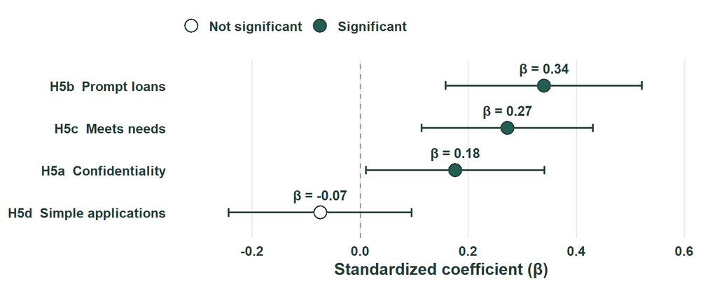

Figure 2: Standardized effect (β) of each driver, with 95% confidence intervals

```r
std_ci <- confint(h5_std)[-1, ]
tibble(label = c("H5a  Confidentiality", "H5b  Prompt loans",
                 "H5c  Meets needs", "H5d  Simple applications"),
       beta = coef(h5_std)[-1], lo = std_ci[, 1], hi = std_ci[, 2],
       sig = summary(h5_std)$coefficients[-1, 4] < .05) |>
  mutate(label = fct_reorder(label, beta)) |>
  ggplot(aes(beta, label)) +
  geom_vline(xintercept = 0, color = "#9a9a9a", linetype = "dashed") +
  geom_errorbarh(aes(xmin = lo, xmax = hi), height = 0.2, color = ink, linewidth = 0.8) +
  geom_point(aes(fill = sig), shape = 21, size = 5, color = ink, stroke = 1) +
  geom_text(aes(label = sprintf("β = %.2f", beta)), vjust = -1.2, color = ink,
            fontface = "bold", size = 4.4) +
  scale_fill_manual(values = c(`TRUE` = green, `FALSE` = "white"),
                    labels = c(`TRUE` = "Significant", `FALSE` = "Not significant"), name = NULL) +
  scale_x_continuous(limits = c(-0.3, 0.6)) +
  labs(x = "Standardized coefficient (β)", y = NULL) +
  theme(legend.position = "top", legend.justification = "left",
        legend.text = element_text(color = ink, face = "bold"),
        panel.grid.major.y = element_blank())
```

### Assumption checks

**Show R code**

```r
h5_vif   <- vif(h5_fit)
h5_bp    <- bptest(h5_fit)
outliers <- which(abs(rstudent(h5_fit)) > 3)
h5_fit2  <- lm(Q37_r ~ q31 + q32 + q33 + q34, data = h5[-outliers, ])   # without outliers
```

**Show R code**

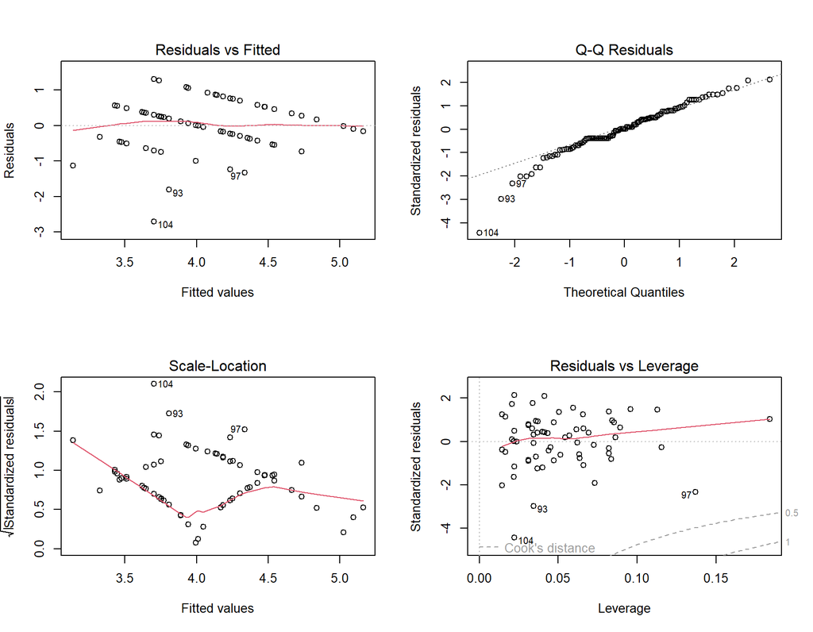

Figure 3: Regression diagnostic plots

```r
par(mfrow = c(2, 2))
plot(h5_fit)
par(mfrow = c(1, 1))
```

**Show R code**

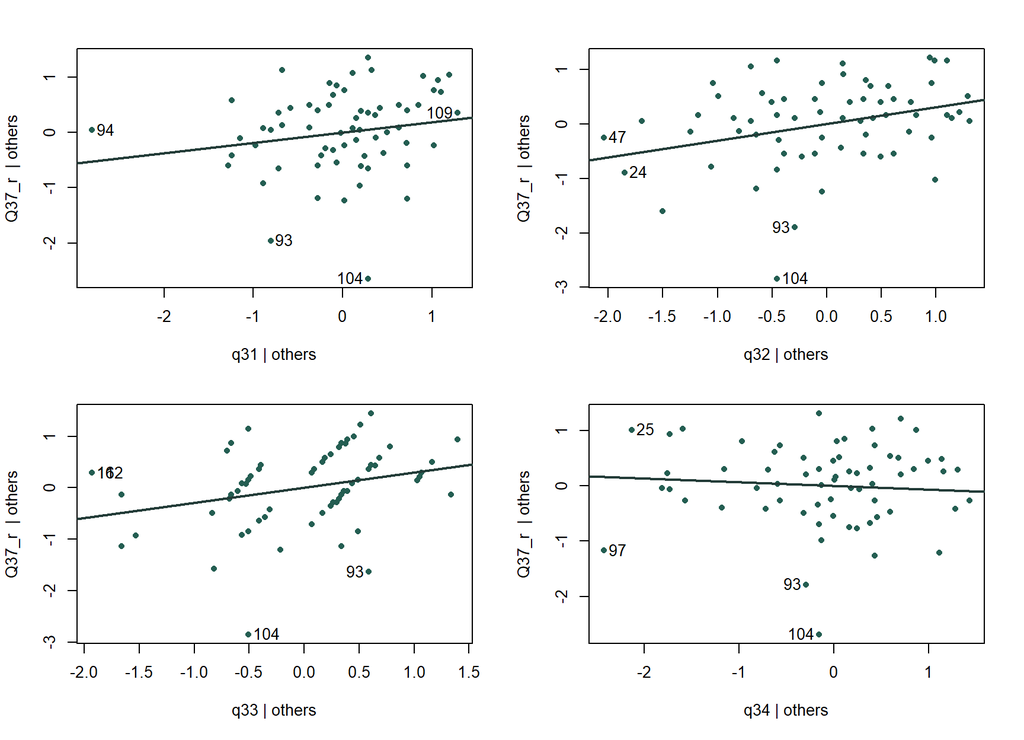

Figure 4: Added-variable plots: each driver’s unique relationship with Q37r, holding the others constant

```r
avPlots(h5_fit, col = green, col.lines = ink, pch = 16, grid = FALSE, main = "")
```

The model **passes its checks** (Figure 3, Figure 4):

- **No overlap problem:** all VIF ≤ 1.40.
- **Constant variance:** Breusch-Pagan *p* = 0.332.
- **Residuals:** the stripes are normal for 1–5 ratings. The lower tail is a bit long because **2 members** (cases 93 and 104) rated EFCU poorly overall despite middling answers on the four drivers. **Refitting without them gives the same results** (*R*² = 0.32), so they stay in.

## H5: Insight

**Members judge EFCU’s management on LOAN SPEED, whether services MEET THEIR NEEDS, and PRIVACY. Paperwork doesn’t move the needle.**

- **Together the four drivers explain 30%** of the overall rating (*R*² = .30, *p* < .001; Table 2).
- **H5b supported: loan speed matters MOST.** Each extra point on Q32 goes with a **+0.31** higher overall rating (β = .34, *p* < .001; Figure 2).
- **H5c supported: meeting needs is a close second.** **+0.29** per point (β = .27, *p* < .001).
- **H5a supported: confidentiality matters, but less.** **+0.19** per point (β = .18, *p* = .036).
- **H5d NOT supported: simple applications make no difference** once the others are counted (β = −.07, *p* = .390). They barely relate to the overall rating even on their own (*r* = .08; Table 1).
- **So what:** **faster loan processing** is EFCU’s biggest lever. Next, close the **“meets my needs” gap** (only **61%** agree), and keep **privacy** strong.

## Summary

| Hypothesis | Driver | β | *p* | Result |
| --- | --- | --- | --- | --- |
| **H5a** | Confidentiality (Q31) | .18 | .036 | **Supported** |
| **H5b** | Prompt loan processing (Q32) | **.34** | < .001 | **Supported: strongest** |
| **H5c** | Services meet needs (Q33) | .27 | < .001 | **Supported** |
| **H5d** | Simple loan applications (Q34) | −.07 | .390 | **Not supported** |

# Appendix

- **GitHub Repository:** [Case 31 H5a-H5d](https://github.com/Simrank-DM/IBM6500-F26/tree/main/IC-Case%2031/IC-Case%2031%20-%20Summary%20of%20Data%20Analysis%20for%20H5a-H5d)
- **GitHub Pages:** [Case 31 H5a-H5d Report](https://simrank-dm.github.io/IBM6500-F26/IC-Case%2031/IC-Case%2031%20-%20Summary%20of%20Data%20Analysis%20for%20H5a-H5d/IC-Case31-Summary-H5a-H5d-Simran-Kaur.html)